# Инфузории в фекалиях лошадей Part 2

В. М. Хайтов

2025-11-15

## Данные для анализа

| Name | Sex | Origin | Type | C.edentatum | C.bipalmatum | T.parvum | T.unifasciculatum | T.caudatum | H.macrotricha | P.ampulla | Bundleia.sp | F.ovalis | P.colpoidea | D.quadrata. | B.curvigula | B.microcorys | C.minimum | B.angusta | S.confusum | C. periachtum | T. dogieli | A. intestinalis | D. brevinucleatum | D.funinucleum | Sp. equi |
| --- | --- | --- | --- | --- | --- | --- | --- | --- | --- | --- | --- | --- | --- | --- | --- | --- | --- | --- | --- | --- | --- | --- | --- | --- | --- |
| Енисей | m | Or | Вольный | 0.25 | 0.33 | 0.67 | 6.00 | 9.33 | 30.01 | 54.67 | 64.67 | 11.00 | 0.25 | 0.00 | 6.67 | 0.00 | 0.00 | 0.00 | 0.00 | 0.00 | 0 | 0.00 | 0.0 | 0 | 0 |
| Олива | f | Fr | Вольный | 0.25 | 0.25 | 3.67 | 0.67 | 4.33 | 36.33 | 58.33 | 98.33 | 15.00 | 0.25 | 0.00 | 12.33 | 0.00 | 0.00 | 0.25 | 0.00 | 0.00 | 0 | 0.00 | 0.0 | 0 | 0 |
| Рица | f | Hu | Вольный | 2.33 | 0.67 | 0.25 | 0.67 | 0.67 | 0.33 | 3.67 | 7.33 | 3.33 | 0.00 | 3.67 | 1.00 | 1.67 | 0.00 | 0.00 | 0.00 | 0.00 | 0 | 0.00 | 0.0 | 0 | 0 |
| Саба | f | Hu | Вольный | 0.25 | 0.67 | 2.67 | 0.33 | 0.25 | 4.33 | 4.33 | 18.00 | 3.00 | 0.00 | 3.00 | 6.00 | 0.67 | 0.00 | 0.00 | 0.00 | 0.00 | 0 | 0.00 | 0.0 | 0 | 0 |
| Филипп | m | Or | Вольный | 0.25 | 0.67 | 0.33 | 0.67 | 0.25 | 8.67 | 7.33 | 7.33 | 3.00 | 0.25 | 5.67 | 4.67 | 4.00 | 1.33 | 0.00 | 0.00 | 0.00 | 0 | 0.00 | 0.0 | 0 | 0 |
| Аржаан | m | Or | Вольный | 1.00 | 2.00 | 2.67 | 2.00 | 2.67 | 26.33 | 17.00 | 33.67 | 2.67 | 0.00 | 1.67 | 8.00 | 0.00 | 0.00 | 0.00 | 0.00 | 0.00 | 0 | 0.00 | 0.0 | 0 | 0 |
| Арга | f | Hu | Вольный | 0.25 | 0.25 | 1.00 | 0.33 | 2.00 | 25.00 | 36.67 | 23.67 | 2.67 | 0.00 | 0.00 | 5.00 | 0.00 | 0.00 | 0.00 | 0.00 | 0.00 | 0 | 0.00 | 0.0 | 0 | 0 |
| Шикра | f | Hu | Вольный | 1.67 | 6.00 | 1.33 | 0.67 | 3.33 | 6.33 | 9.33 | 15.33 | 3.67 | 0.25 | 3.00 | 2.33 | 0.00 | 0.00 | 0.00 | 0.00 | 0.33 | 0 | 0.00 | 0.0 | 0 | 0 |
| Помпей | m | Hu | Загон | 4.00 | 2.67 | 0.25 | 0.00 | 0.25 | 0.00 | 2.67 | 5.33 | 0.25 | 0.00 | 1.33 | 8.00 | 2.67 | 0.00 | 0.00 | 0.00 | 0.00 | 0 | 0.00 | 0.0 | 0 | 0 |
| Паприка | f | Fr | Вольный | 0.33 | 0.33 | 0.25 | 1.33 | 0.67 | 0.67 | 2.00 | 4.00 | 0.25 | 0.00 | 0.67 | 1.33 | 0.00 | 0.00 | 0.00 | 0.00 | 0.33 | 0 | 0.00 | 0.0 | 0 | 0 |
| Эниф | m | Or | Загон | 0.67 | 0.25 | 0.00 | 0.25 | 0.25 | 0.00 | 0.00 | 2.00 | 0.00 | 0.00 | 0.00 | 0.33 | 0.67 | 0.33 | 0.00 | 0.00 | 0.00 | 0 | 0.00 | 0.0 | 0 | 0 |
| Буда | m | Or | Загон | 0.25 | 0.67 | 0.33 | 1.00 | 0.33 | 0.67 | 1.00 | 2.67 | 0.00 | 0.00 | 0.25 | 1.67 | 0.67 | 0.67 | 0.25 | 0.25 | 1.00 | 0 | 0.00 | 0.0 | 0 | 0 |
| Лаванда | f | Fr | Вольный | 0.67 | 0.33 | 0.25 | 0.25 | 0.25 | 0.33 | 1.00 | 0.25 | 0.00 | 0.25 | 0.25 | 0.33 | 0.00 | 0.25 | 0.00 | 0.00 | 0.00 | 0 | 0.00 | 0.0 | 0 | 0 |
| Сангрия | f | Fr | Вольный | 0.67 | 0.25 | 0.25 | 0.25 | 0.25 | 1.33 | 2.00 | 0.00 | 0.00 | 0.00 | 0.00 | 0.33 | 0.00 | 0.00 | 0.00 | 0.25 | 0.00 | 0 | 0.00 | 0.0 | 0 | 0 |
| домашняя 1 | NA | NA | Домашняя | 2.00 | 0.00 | 0.00 | 0.00 | 1.00 | 0.00 | 0.00 | 0.60 | 0.00 | 0.00 | 0.00 | 0.60 | 1.20 | 0.00 | 0.33 | 1.00 | 0.00 | 1 | 1.33 | 0.0 | 0 | 2 |
| домашняя 2 | NA | NA | Домашняя | 0.00 | 0.00 | 5.00 | 2.00 | 2.00 | 0.00 | 0.00 | 1.00 | 0.00 | 0.00 | 0.10 | 0.10 | 1.00 | 0.10 | 0.10 | 2.00 | 1.00 | 3 | 0.33 | 0.1 | 2 | 3 |

## Сравнение групп лошадей по составу сообщества инфузорий

Ординация сообществ на основе матрицы коэффициентов Брей-Куртиса

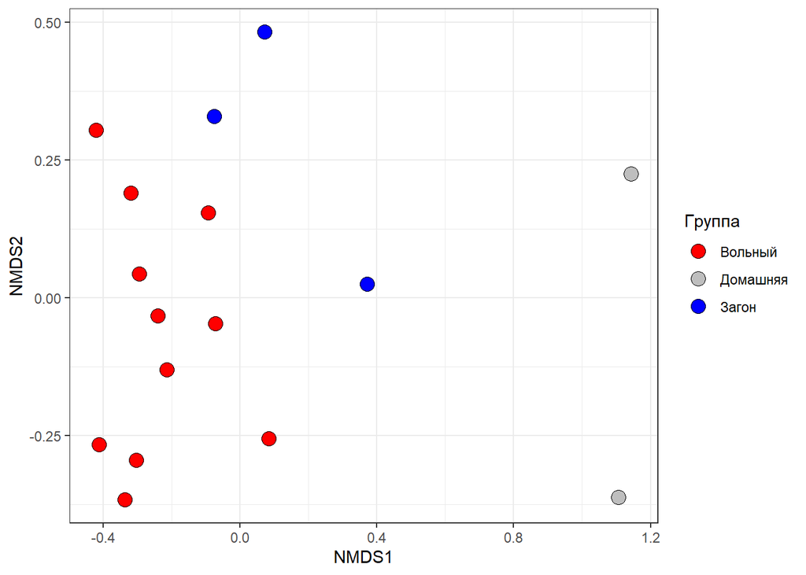

На ординации хорошо видно, что сообщество инфузорий домашних лошадей сильно отличается от сообщества лошадей Пржевальского. У последних также отличаются сообщества у лошадей из загона и у лошадей из вольного выпаса.

Для трактовки связей видов с типом местообитания приводим ординацию в тех же осях видов

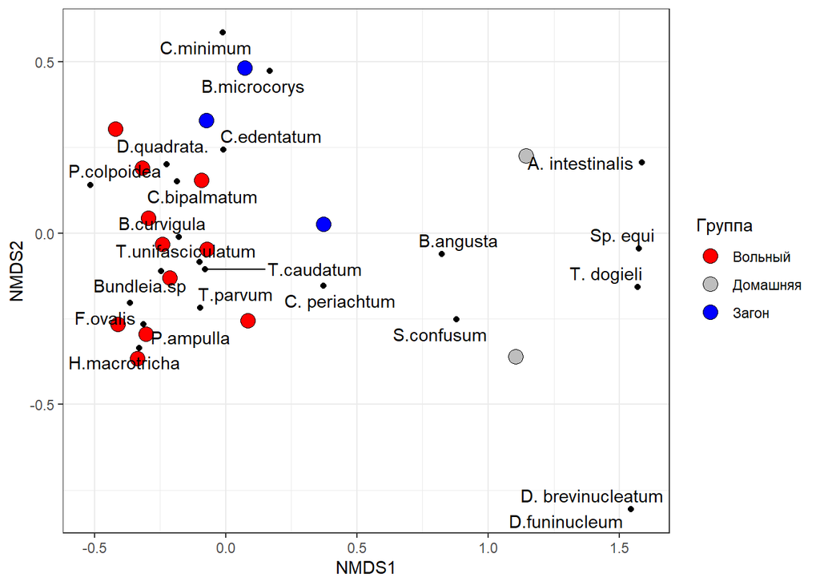

Для домашних лошадей характерны A.intestinalis, Sp.equi, T.dogeli, D.funinucleum, D.brevinucleum. Возможно это какие-то виды-специалисты, которые в качестве хозяина испоьзуют только домашних лошадей.

Виды, которые Характерны для двух видов лошадей, занимают промежуточную позицию: B.angusta, S.confusum, C.periactum. Возможно это какие-то виды универсалы, которым важно, чтобы хозяин был лошадью, а вид хозяина не столь важен.

Виды, которые характерны для загонных лошадей Пржевальского: C.edentatum, B.microcorys, C.minimum

Все остальные виды характеризуют сообщество инфузорий вольных лошадей Пржевальсткого.

**Важно!** Попробуйте прикинуть нет ли чего-то общего у видов инфузорий из указанных групп (размер, форма тела, что-то про клетку, по филогенетическое родство и т.п.). Если тут есть за что зацепиться, то будем думать каким анализом это вытащить.

Далее будем анализировать только лошадей Пржевальского. Вот ординация сообщества инфузорий для них.

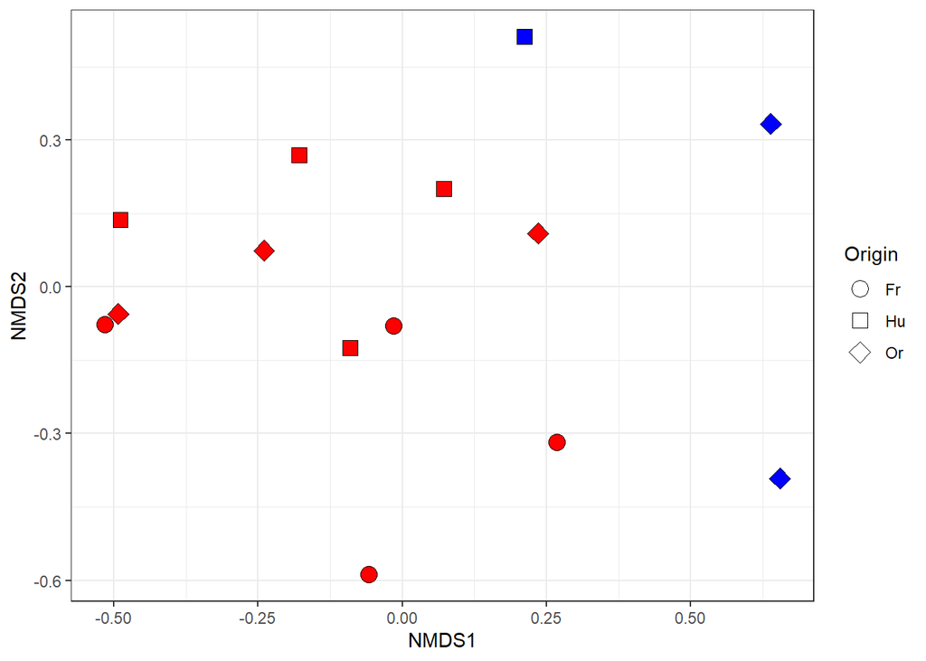

Для проверки статистической значимости влияния факторов на структуру сообщества применяем PERMANOVA (10000 пермутаций).

| term | df | SumOfSqs | R2 | statistic | p.value |
| --- | --- | --- | --- | --- | --- |
| Sex | 1 | 0.2293646 | 0.0722111 | 1.282354 | 0.2658734 |
| Type | 1 | 0.7015342 | 0.2208646 | 3.922206 | 0.0107989 |
| Origin | 2 | 0.8092221 | 0.2547681 | 2.262139 | 0.0416958 |
| Residual | 9 | 1.6097592 | 0.5068019 | NA | NA |
| Total | 13 | 3.1763086 | 1.0000000 | NA | NA |

```
##
## Contrast: Вольный_Загон
##
##                    average       sd    ratio      ava      avb cumsum      p
## Bundleia.sp        0.19901  0.10373  1.91840 24.78000  3.33300  0.278 0.4034
## P.ampulla          0.13901  0.09879  1.40710 17.84800  1.22300  0.472 0.3954
## H.macrotricha      0.10738  0.07810  1.37490 12.69600  0.22300  0.622 0.3613
## B.curvigula        0.06011  0.05990  1.00350  4.36300  3.33300  0.706 0.1547
## F.ovalis           0.03803  0.02797  1.35960  4.05400  0.08300  0.759 0.2057
## D.quadrata.        0.03112  0.03426  0.90840  1.63000  0.52700  0.802 0.3685
## B.microcorys       0.02815  0.02577  1.09250  0.57600  1.33700  0.842 0.0554 .
## C.edentatum        0.02449  0.02961  0.82720  0.72000  1.64000  0.876 0.1174
## C.bipalmatum       0.02143  0.02678  0.80020  1.06800  1.19700  0.906 0.2588
## T.caudatum         0.01596  0.01625  0.98260  2.18200  0.27700  0.928 0.5107
## T.unifasciculatum  0.01382  0.01508  0.91700  1.19700  0.41700  0.947 0.3251
## T.parvum           0.01268  0.01327  0.95550  1.21300  0.19300  0.965 0.3037
## C.minimum          0.00919  0.01048  0.87720  0.14400  0.33300  0.978 0.0667 .
## C. periachtum      0.00867  0.01552  0.55900  0.06000  0.33300  0.990 0.1910
## S.confusum         0.00255  0.00528  0.48300  0.02300  0.08300  0.994 0.2456
## P.colpoidea        0.00248  0.00546  0.45390  0.11400  0.00000  0.997 0.2443
## B.angusta          0.00206  0.00409  0.50290  0.02300  0.08300  1.000 0.1841
## T. dogieli         0.00000  0.00000      NaN  0.00000  0.00000  1.000     NA
## A. intestinalis    0.00000  0.00000      NaN  0.00000  0.00000  1.000     NA
## D. brevinucleatum  0.00000  0.00000      NaN  0.00000  0.00000  1.000     NA
## D.funinucleum      0.00000  0.00000      NaN  0.00000  0.00000  1.000     NA
## Sp. equi           0.00000  0.00000      NaN  0.00000  0.00000  1.000     NA
## ---
## Signif. codes:  0 '***' 0.001 '**' 0.01 '*' 0.05 '.' 0.1 ' ' 1
## Permutation: free
## Number of permutations: 10000
```

При этом первые три вида имеют обилие на порядок больше в группе вольных (колонка ava) по сравнению с группой загонных (avb).

Можно ли что-то сказать про эти виды? Опять же они могут чем-то быть похожи.